# Exploratory Data Analysis: An objective analysis of Donald Trump’s facebook activity

James Dayhuff

October 22, 2016

## Data origins

This data was collected by another individual using open source technology such as python and git. The data was then published to the public for free analysis. The data can be found at this location: https://docs.google.com/spreadsheets/d/1mLO7SFqHmUaZEpp87cwkM0luJutSwmwKMx7kaM9348U/edit

## Questions to answer

Here are a few questions I’m hoping to answer through my analysis:

- How did Trump’s Facebook activity change after he announced his presidential candidacy?
- What is the most common response from other Facebook users to his Facebook posts?
- Were these responses different before he announced his candidacy?
- What were some contributing factors to some of his most popular posts? (date, subject, type of post, etc)

## Cleaning the data

The data came in an xlsx format via a public google sheet. Once the data was downloaded to my local file system, I converted it to a csv file and attempted to read it into R-Studio. I immediately ran into problems with the formatting of the data. The biggest issue was the “status_message” column, which included Facebook status messages with all the punctuation included. Read.csv() misinterpreted the punctuation in the status messages and it threw off the formatting. After removing the punctuation in excel with the “find and replace” functionality, I easily imported the data into R-Studio.

## Data Summary

```
##                           status_id                      status_message
##                                :   2                            : 318
##  153080620724_10157772965135725:   2                            :  36
##  153080620724_101389543260237  :   1   #TrumpAdvice             :  21
##  153080620724_10150126653070554:   1   MAKE AMERICA GREAT AGAIN :  12
##  153080620724_10150142451675725:   1   #MakeAmericaGreatAgain   :   2
##  153080620724_10150370919630725:   1   (Other)                  :3758
##  (Other)                       :4154   NA's                     :  15
##                                                           link_name
##  Timeline Photos                                               :1137
##                                                                : 737
##                                                                : 710
##  Join Donald J Trump for President   2015 & 2016 Campaign Trail: 203
##  2016 GOP CONVENTION                                           : 107
##  Donald J Trump s cover photo                                  :  31
##  (Other)                                                       :1237
##  status_type            status_published num_reactions
##        :   2   1/1/2016 17:44:09:  18    Min.   :      7
##  event :   1   1/1/2016 14:41:37:  16    1st Qu.:   9306
##  link  : 764   1/1/2016 18:53:23:  16    Median :  42596
##  photo :1539   1/1/2016 18:53:22:  15    Mean   :  56156
##  status:1177   1/1/2016 16:30:35:  14    3rd Qu.:  80102
##  video : 679   7/21/2016 4:34:51:  12    Max.   :1117712
##                (Other)          :4071    NA's   :2
##   num_comments      num_shares         num_likes         num_loves
##  Min.   :     3   Min.   :     0.0   Min.   :      7   Min.   :    0
##  1st Qu.:   816   1st Qu.:   337.5   1st Qu.:   9277   1st Qu.:    0
##  Median :  3456   Median :  3146.5   Median :  39964   Median :    0
##  Mean   :  5111   Mean   :  7559.6   Mean   :  53049   Mean   : 1853
##  3rd Qu.:  6255   3rd Qu.:  7562.5   3rd Qu.:  75516   3rd Qu.: 2679
##  Max.   :319745   Max.   :812775.0   Max.   :1117712   Max.   :53786
##  NA's   :2        NA's   :2          NA's   :2         NA's   :2
##     num_wows         num_hahas          num_sads         num_angrys
##  Min.   :    0.0   Min.   :    0.0   Min.   :    0.0   Min.   :    0.0
##  1st Qu.:    0.0   1st Qu.:    0.0   1st Qu.:    0.0   1st Qu.:    0.0
##  Median :    0.0   Median :    0.0   Median :    0.0   Median :    0.0
##  Mean   :  167.1   Mean   :  405.8   Mean   :  129.9   Mean   :  545.5
##  3rd Qu.:  163.2   3rd Qu.:  176.0   3rd Qu.:   28.0   3rd Qu.:  218.2
##  Max.   :27889.0   Max.   :81198.0   Max.   :22576.0   Max.   :84015.0
##  NA's   :2         NA's   :2         NA's   :2         NA's   :2
```

The columns are as listed:

- status_id
- status_message
- link_name
- status_type
- status_published
- num_reactions
- num_comments
- num_shares
- num_likes
- num_loves
- num_wows
- num_hahas
- num_sads
- num_angrys

## Data Structures

Here is the structure of the data, along with the data types contained in this data set.

```
## 'data.frame':    4162 obs. of  14 variables:
##  $ status_id       : Factor w/ 4160 levels " ","153080620724_101389543260237",..: 3870 3869 3868 3867 3866 3865 3864 3863 3841 3862 ...
##  $ status_message  : Factor w/ 3746 levels ""," ","   Donald Trump backs  Apprentice  Randal Pinkett for N J  Lieutenant Governor: http://tinyurl com/mvovzb",..: 503 3075 677 1868 826 2232 3322 3439 481 368 ...
##  $ link_name       : Factor w/ 1109 levels ""," "," Nuestro amigo : In Donald Trump  some Latinos see a friend and ally",..: 922 2 2 570 714 2 1 1 1 1 ...
##  $ status_type     : Factor w/ 6 levels " ","event","link",..: 4 6 6 3 3 5 5 5 6 5 ...
##  $ status_published: Factor w/ 3932 levels " ","1/1/2014 0:39:08",..: 452 451 450 449 448 447 446 445 453 434 ...
##  $ num_reactions   : int  6813 33768 85627 22696 40729 51108 83038 144823 95328 81179 ...
##  $ num_comments    : int  543 3644 8810 3665 4905 6773 6547 6975 7452 6137 ...
##  $ num_shares      : int  359 17653 32594 5082 17087 3266 8109 10088 68260 2785 ...
##  $ num_likes       : int  6178 26649 73519 14029 26472 45046 71491 136689 82044 75008 ...
##  $ num_loves       : int  572 487 2943 122 178 684 1078 6688 4379 4927 ...
##  $ num_wows        : int  39 1155 1020 2091 2588 213 759 105 656 109 ...
##  $ num_hahas       : int  17 75 330 241 154 229 498 919 6184 173 ...
##  $ num_sads        : int  0 191 263 286 417 290 306 61 218 136 ...
##  $ num_angrys      : int  7 5211 7552 5927 10922 4646 8907 363 1847 826 ...
```

As seen above (or if it isn’t rendering properly), the data types found in the data are listed below.

- Factor
- int

## Exploratory Statistics

By viewing a summary and boxplot of the overall reactions, I can already see that a lot of work needs to be done on the data. There are an overwhelming amount of outliers, which means the data is heavily skewed and would best be analyzed by taking subsets of the data, most likely depending on the status_published date variable.

```
##    Min. 1st Qu.  Median    Mean 3rd Qu.    Max.    NA's
##       7    9306   42600   56160   80100 1118000       2
```

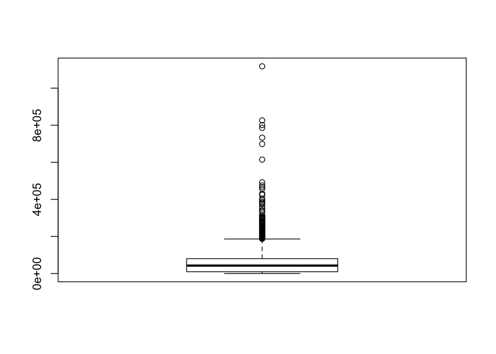

## Exploratory Plots

These initial plots help me understand the data at a high level. Identifying possible trends and areas of interest will help me answer my questions.

### Barplot of types of reactions

An initial plotting of the reactions to his Facebook posts is interesting. You’ll notice an overwhelming majority of the reactions belong to a single category. This is mostly due to Facebook’s reaction updates within the past year to add more emotions for various reactions, instead of the single “like” button.

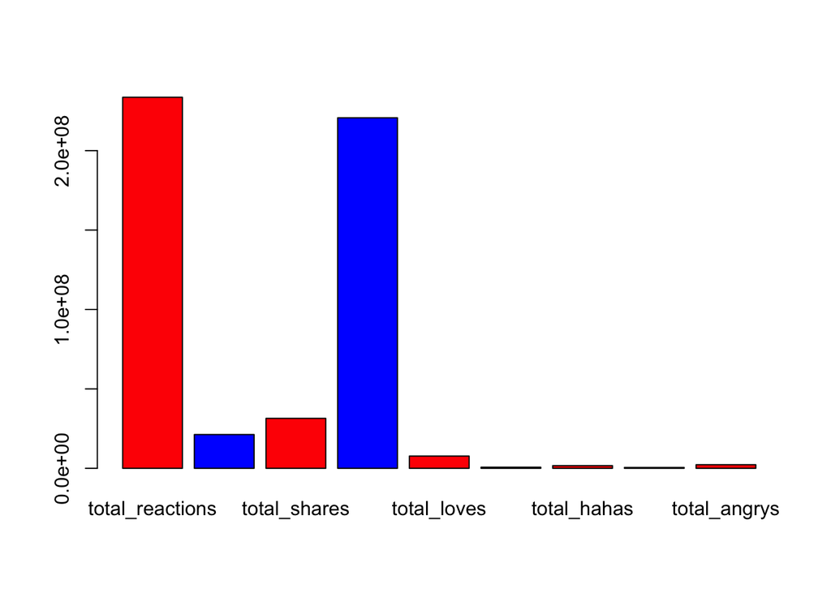

### Timeline scatter plot of reactions

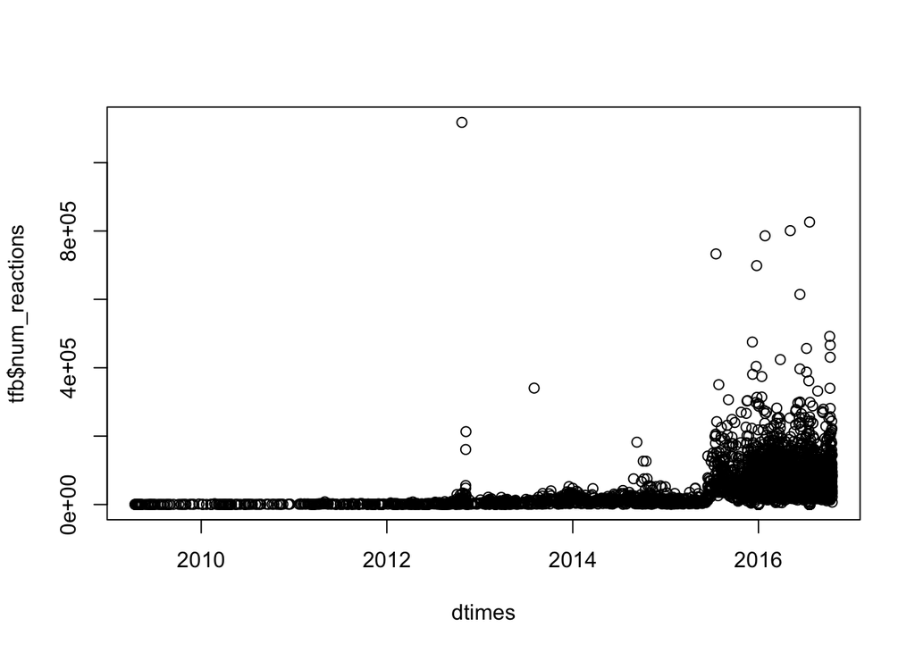